# Praca domowa 1- EDA

# 1 Wstęp

Naszym zadaniem było przygotowane wstępnej analizy eksploracyjnej zbioru danych [Lisbon House Prices](https://www.kaggle.com/cgrodrigues/lisbon-house-prices), dotyczącego mieszkań i ich ceny w Lisbonie

# 2 Opis zbioru danych

Zobaczmy najpierw kilka pierwszych wierszy:

| Id | Condition | PropertyType | PropertySubType | Bedrooms | Bathrooms | AreaNet | AreaGross | Parking | Latitude |
| --- | --- | --- | --- | --- | --- | --- | --- | --- | --- |
| 101 | Used | Homes | Apartment | 3 | 1 | 76 | 152 | 0 | 38.7792 |
| 102 | Used | Homes | Duplex | 5 | 3 | 190 | 380 | 0 | 38.7056 |
| 103 | Used | Homes | Apartment | 1 | 1 | 26 | 52 | 0 | 38.7058 |
| 104 | Used | Homes | Apartment | 5 | 4 | 185 | 370 | 0 | 38.7466 |
| 105 | Used | Homes | Apartment | 7 | 1 | 150 | 300 | 0 | 38.7323 |
| 106 | Used | Homes | Apartment | 3 | 2 | 95 | 190 | 0 | 38.6965 |

| Latitude | Longitude | Country | District | Municipality | Parish | Price.M2 | Price |
| --- | --- | --- | --- | --- | --- | --- | --- |
| 38.7792 | -9.1186 | Portugal | Lisboa | Lisboa | Olivais | 2463 | 198000 |
| 38.7056 | -9.1784 | Portugal | Lisboa | Lisboa | Alcantara | 3125 | 1270000 |
| 38.7058 | -9.1639 | Portugal | Lisboa | Lisboa | Estrela | 4005 | 140000 |
| 38.7466 | -9.1640 | Portugal | Lisboa | Lisboa | Sao Domingos de Benfica | 3412 | 995000 |
| 38.7323 | -9.1287 | Portugal | Lisboa | Lisboa | Arroios | 3277 | 570000 |
| 38.6965 | -9.2099 | Portugal | Lisboa | Lisboa | Belem | 3542 | 425000 |

Zobaczmy co oznaczają poszczególne kolumny :

- Condition - stan budynku (nowy, jak nowy, używany, do renowacji)
- PropertyType - typ posiadłości (dom wolno-stojący lub kompleks mieszkaniowy)
- PropertySubType - podtyp posiadłości (apartament, bliźniak, itd…)
- Bedrooms - liczba sypialnii
- Bathrooms - liczba łazienek
- AreaNet/AreaGross - powierzchnia netto/brutto
- Parking - liczba miejsc parkingowych
- Latitude - szerokość geograficzna
- Longitude - wysokość geograficzna
- Country/District/Municipacity - kraj/region/miasto w którym znajduje się posiadłość
- Parish - dzielnica miasta
- Price Sq. M. - cena za metr kwadratowy w lokalizacji posiadłości
- Price - badana zmienna - cena posiadłości

Kolumny takie jak `Country` `District` `Municipality` należy wyrzucić, we wszystkich wierszach to odpowiednio wartości *Portugal*,*Lizbona*,*Lizbona*. Nic to nam nie daję, poza tym informacja ta jest już zawarta w danych geograficznych `Latitude` i`Longitude`.

Zobaczmy podstawowe statystyki danych numerycznych:

|  | Unique count | NA count | Min. | 1st Qu. | Median | Mean | 3rd Qu. | Max. | Sd. |
| --- | --- | --- | --- | --- | --- | --- | --- | --- | --- |
| Bedrooms | 10 | 0 | 0.0000 | 2.0000 | 2.00000 | 2.491870e+00 | 3.000000 | 11.0000 | 1.354484e+00 |
| Bathrooms | 7 | 0 | 0.0000 | 1.0000 | 2.00000 | 1.845528e+00 | 2.000000 | 6.0000 | 1.034369e+00 |
| AreaNet | 123 | 0 | 23.0000 | 64.2500 | 90.00000 | 1.096626e+02 | 145.000000 | 573.0000 | 6.626166e+01 |
| AreaGross | 123 | 0 | 46.0000 | 128.5000 | 180.00000 | 2.193252e+02 | 290.000000 | 1146.0000 | 1.325233e+02 |
| Parking | 4 | 0 | 0.0000 | 0.0000 | 0.00000 | 1.544715e-01 | 0.000000 | 3.0000 | 5.035794e-01 |
| Latitude | 139 | 0 | 38.6963 | 38.7169 | 38.73005 | 3.873311e+01 | 38.745800 | 38.7899 | 2.077770e-02 |
| Longitude | 141 | 0 | -9.2244 | -9.1607 | -9.13680 | -9.140051e+00 | -9.113575 | -9.0938 | 3.235600e-02 |
| Price.M2 | 24 | 0 | 2393.0000 | 2881.0000 | 3402.00000 | 3.487874e+03 | 3859.000000 | 5340.0000 | 7.158961e+02 |
| Price | 160 | 0 | 85000.0000 | 271250.0000 | 450000.00000 | 5.516588e+05 | 715000.000000 | 4150000.0000 | 4.220916e+05 |

i informacje o danych kategorycznych:

|  | Unique count | NA count | Length | Class | Mode |
| --- | --- | --- | --- | --- | --- |
| Condition | 4 | 0 | 246 | character | character |
| PropertyType | 2 | 0 | 246 | character | character |
| PropertySubType | 8 | 0 | 246 | character | character |
| Parish | 24 | 0 | 246 | character | character |

Nie ma wartości `NA` dodatkowo widać. Podejrzana może się wydawać liczba unikalnych wartości `AreaNet` i `AreaGross`, co zostanie poruszone w dalszej części - przy korelacjach.

# 3 Exploratory Data Analysis

## 3.1 Zmienne numeryczne

Analizę danych zacznijmy od wyliczenia korelacji miedzy zmiennymi :

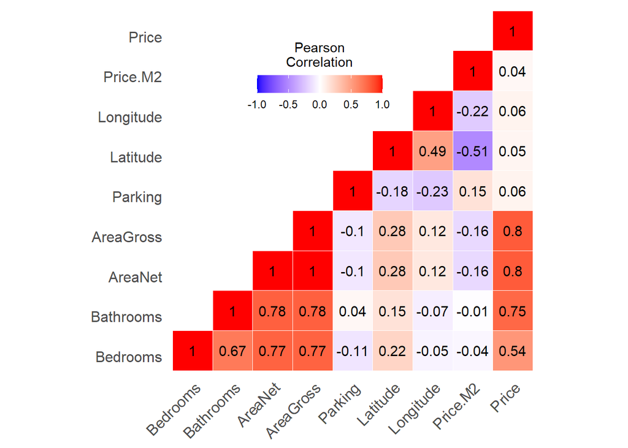

Z powyższego wynika, że warto wyrzucić jedno z `AreaGross` i `AreaNet`.

W celu sprawdzenia rozkładów wartości w naszych danych, przedstawmy je na histogramach:

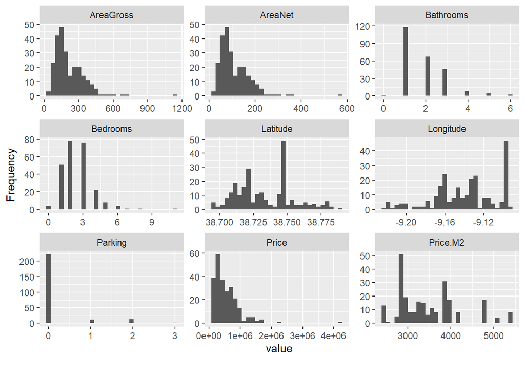

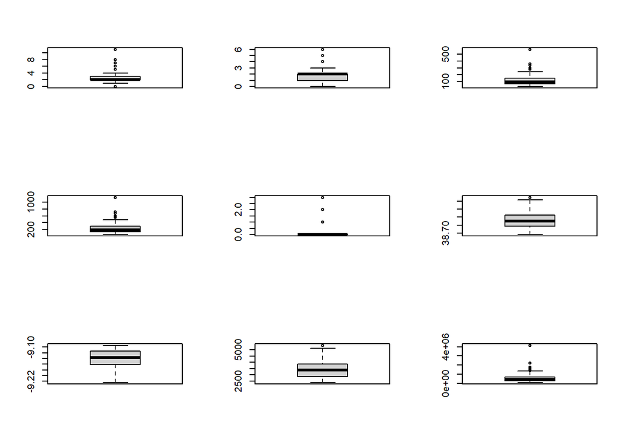

### 3.1.1 Zmienna `AreaNet`

```
##    Min. 1st Qu.  Median    Mean 3rd Qu.    Max.
##   23.00   64.25   90.00  109.66  145.00  573.00
```

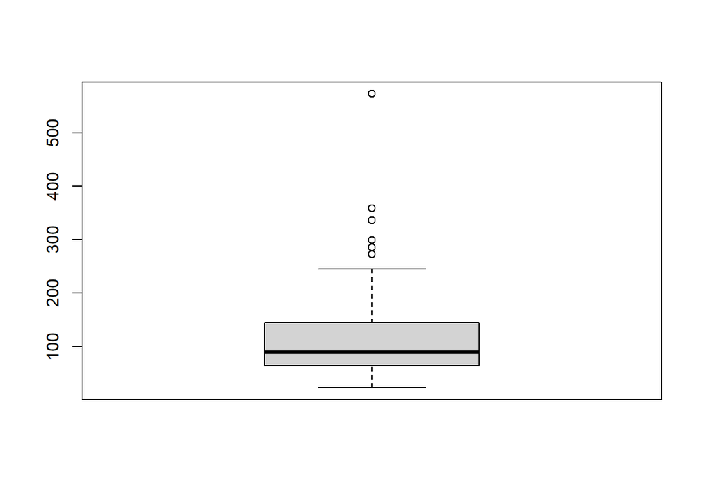

Jak widać rozmiary domów wahają się od 23 do 573 m2. Z wykresu skrzynkowego widać także że typowe rozmiary posiadłości znajdują się w okolicach 100m2

Sprawdźmy zależność między zmiennymi AreaNet i Price :

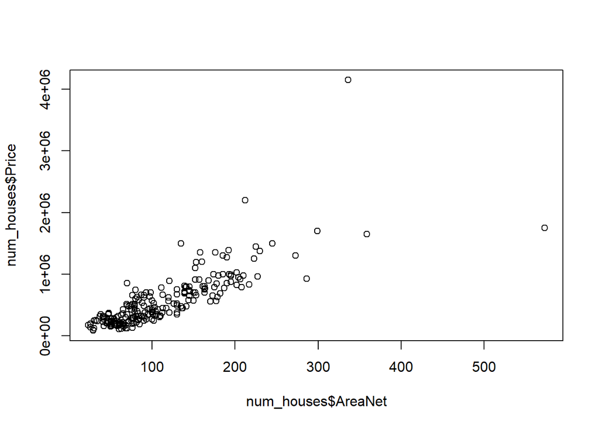

### 3.1.2 Zmienna `Price.M2`

```
##    Min. 1st Qu.  Median    Mean 3rd Qu.    Max.
##    2393    2881    3402    3488    3859    5340
```

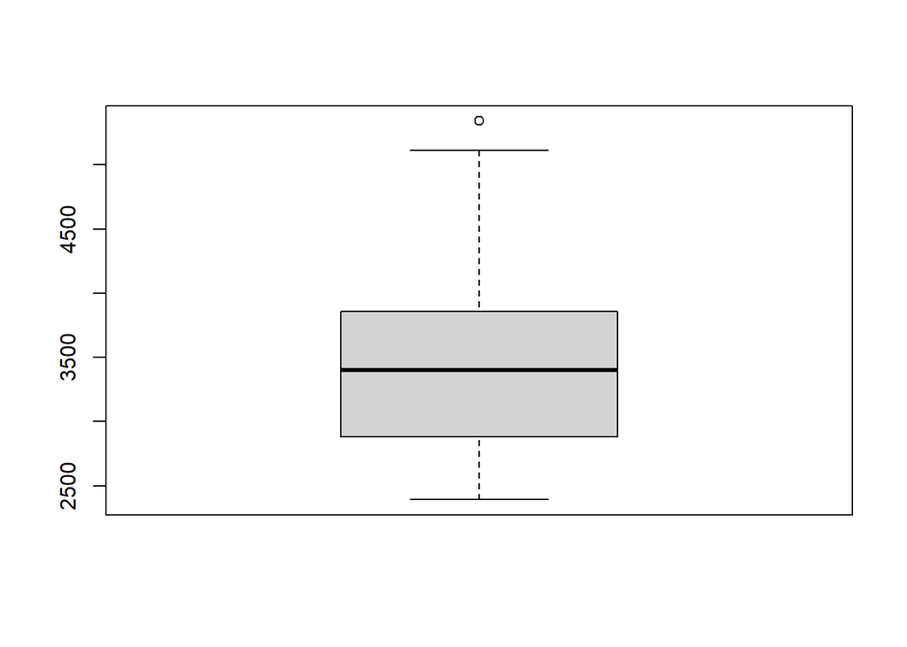

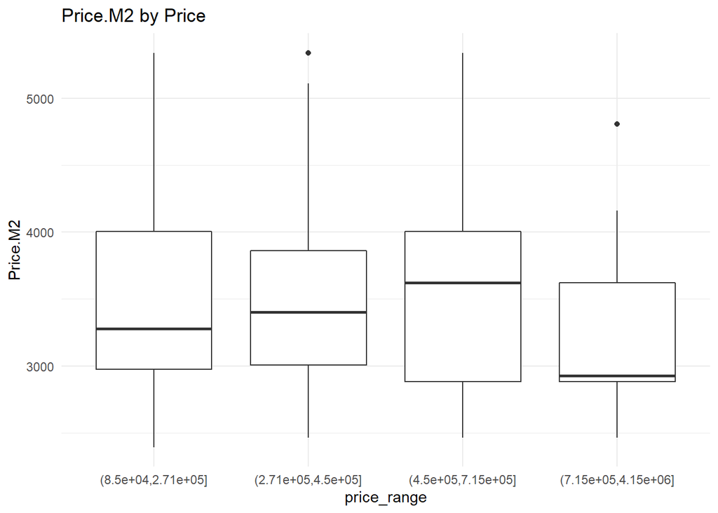

Im droższy dom tym wyższa cena na metr aż do pewnego momentu.

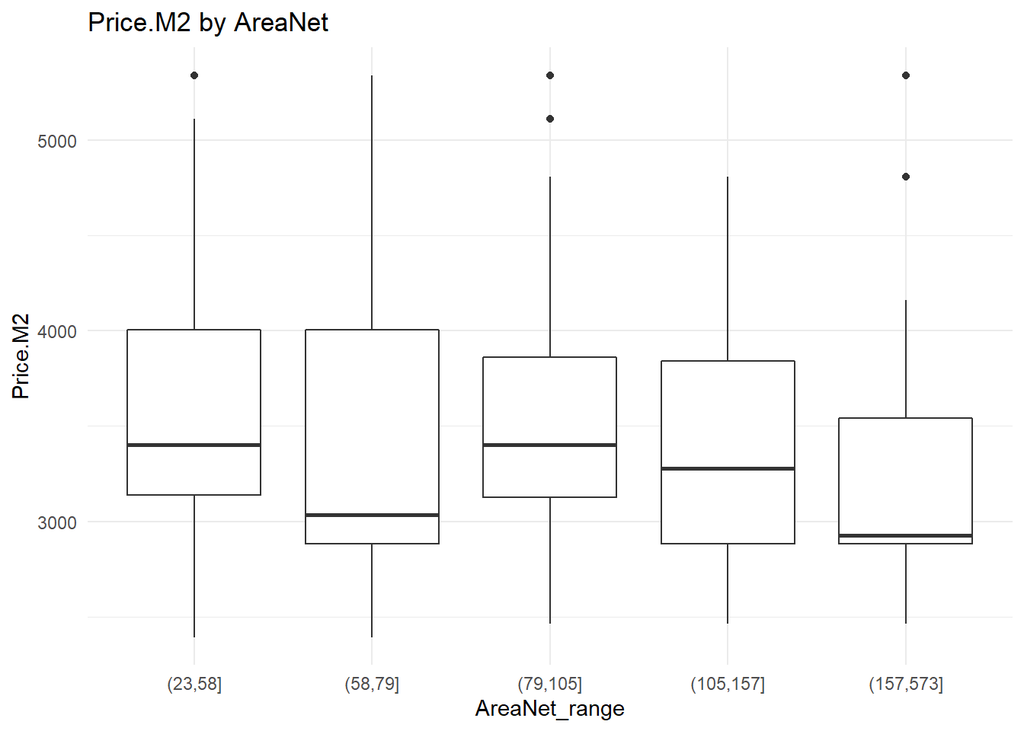

Najdrożej za m2 wychodzą domy małe, natomiast najtaniej te największe.

### 3.1.3 Zmienna `Price`

```
##    Min. 1st Qu.  Median    Mean 3rd Qu.    Max.
##   85000  271250  450000  551659  715000 4150000
```

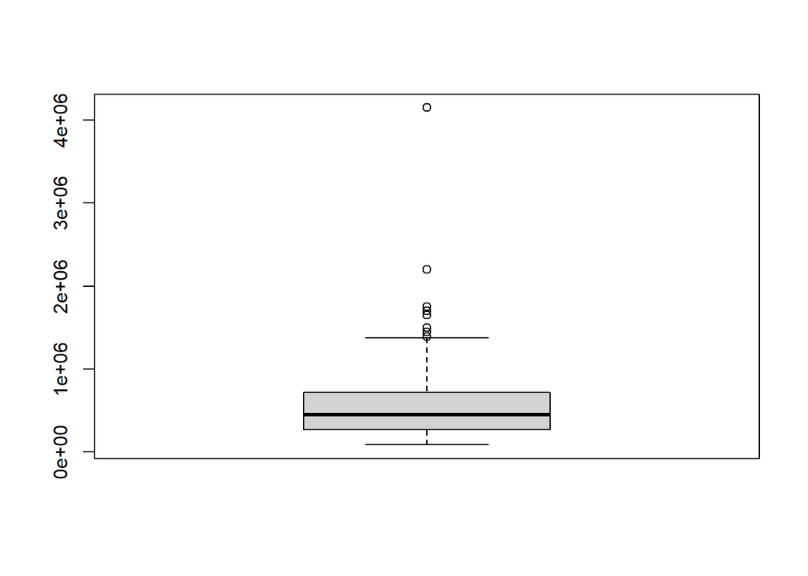

## 3.2 Zmienne kategoryczne

Zobaczmy jak wygląda korelacja miedzy zmiennymi kategorycznymi :

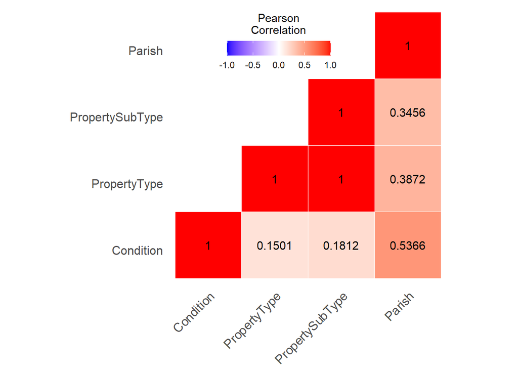

Z powyższego wynika, że warto wyrzucić jedno z `PropertyType` i `PropertySubType`. Tak wysoka wartość korelacji jest spowodowana bezwzględną dominacją podtypu Home, a mianowicie własności Apartment. Mieszkania są ogromną częścią posiadłości w całym data setcie, a w szczególności w kategorii Home przez co istnieje silne powiązanie między nimi.

### 3.2.1 Zmienna `Condition`

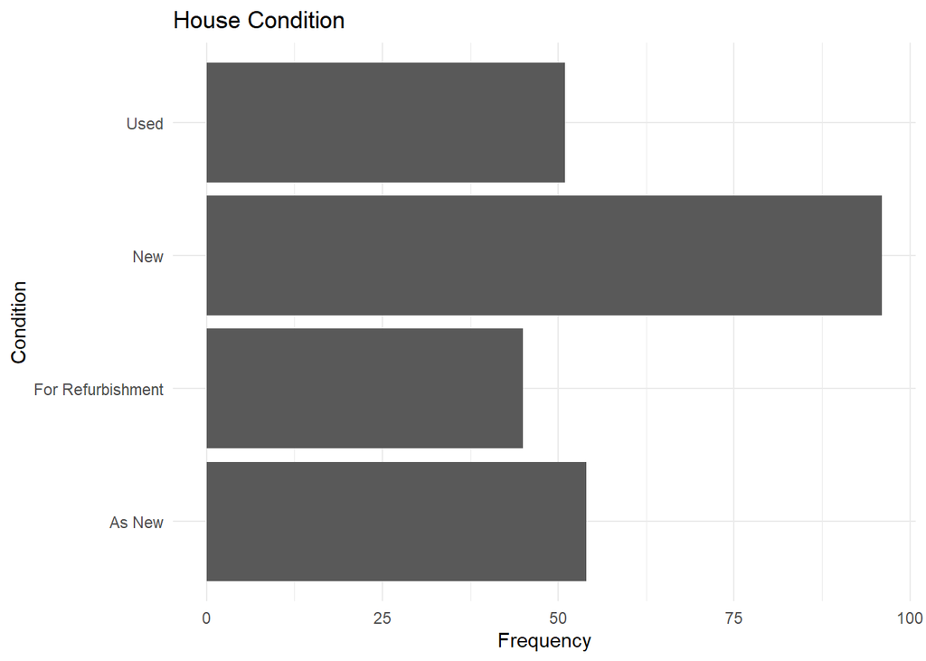

Większość domów jest nowa, albo jak nowa.

### 3.2.2 Zmienna `PropertyType`

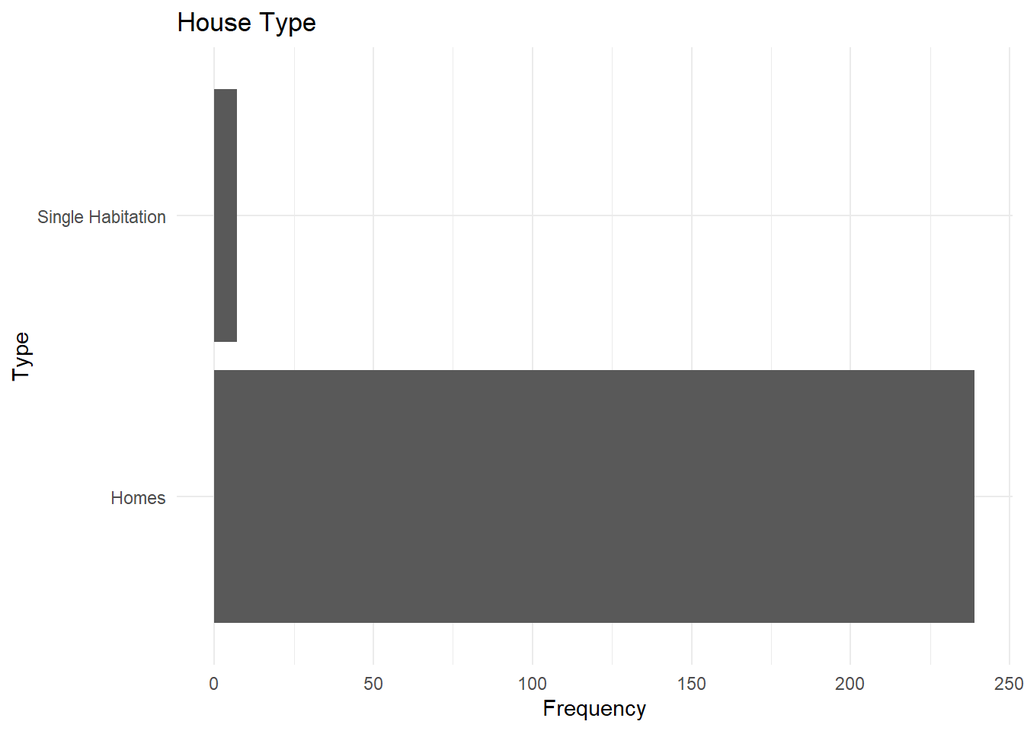

Praktycznie wszystkie lokalizacje są domami.

### 3.2.3 Zmienna `PropertySubType`

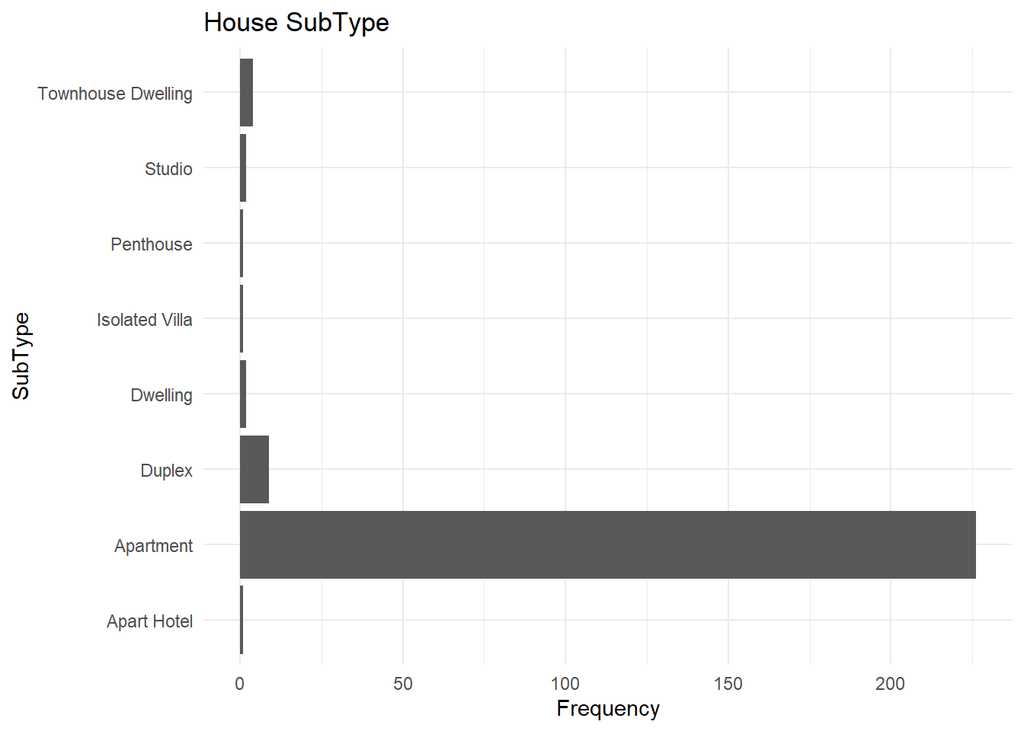

Najczęstszym podrodzajem są apartamenty.

### 3.2.4 Zmienna `Parish`

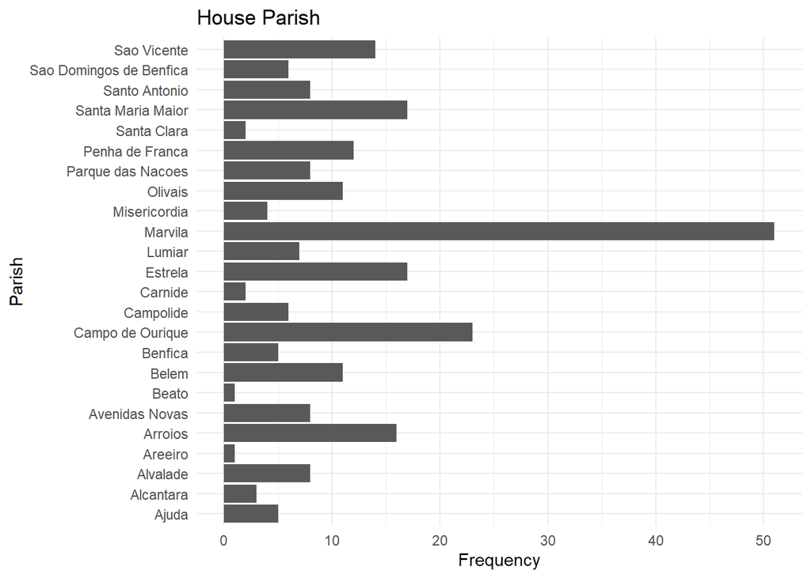

Najpopularniejszą parafią jest z kolei “Marvila”.

## 3.3 Ciekawe zależności między zmiennymi numerycznymi a kategorycznymi

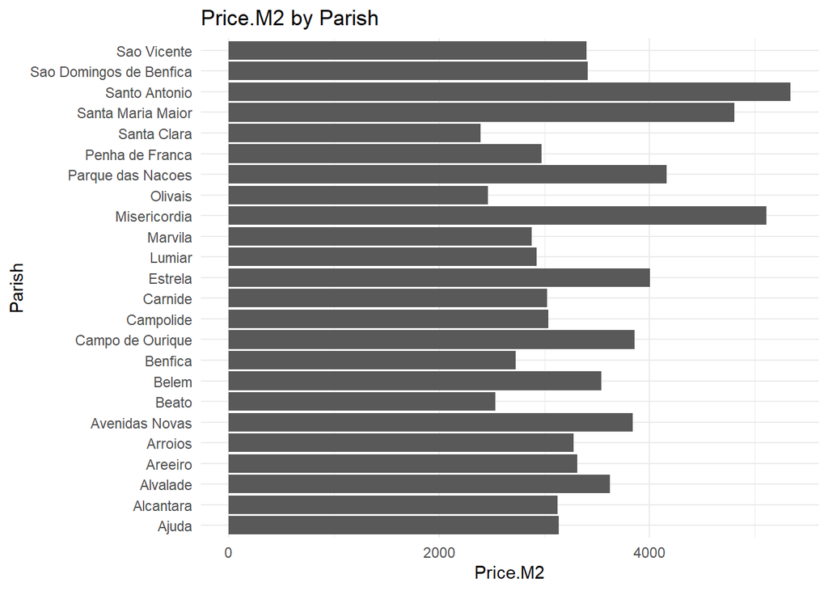

Cena za m2 domu jest najwyższa w “Santo Antonio”, a najniższa w “Santa Clara”.

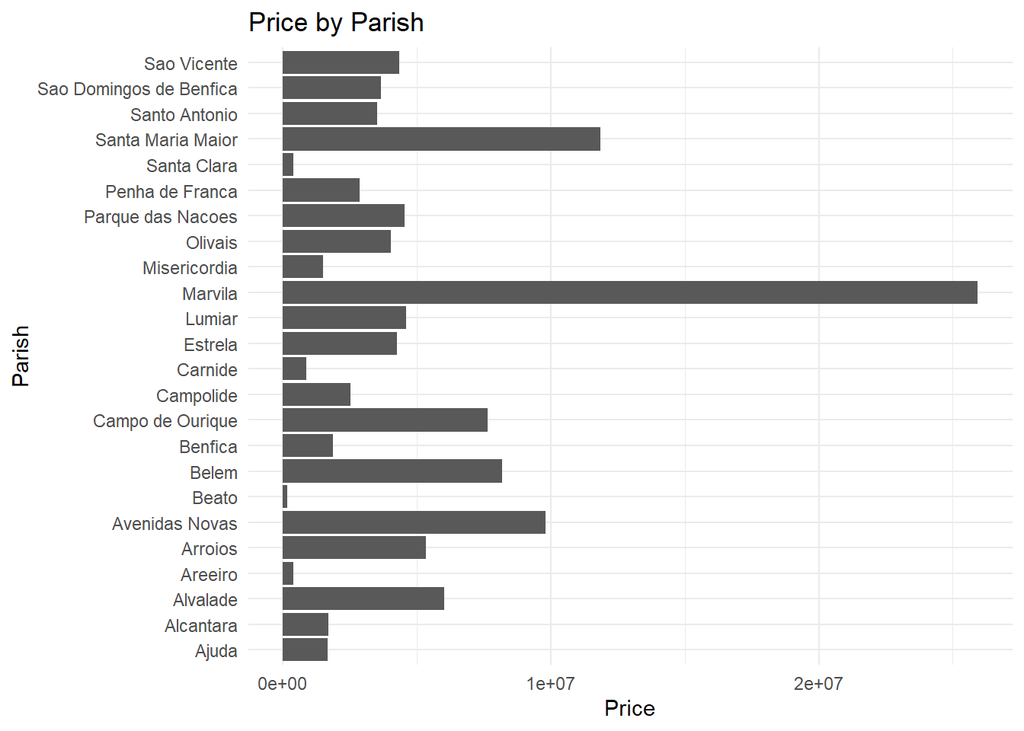

Dlaczego tak? Czy domy w Marvila są po prostu większe niż w Santo Antionio?

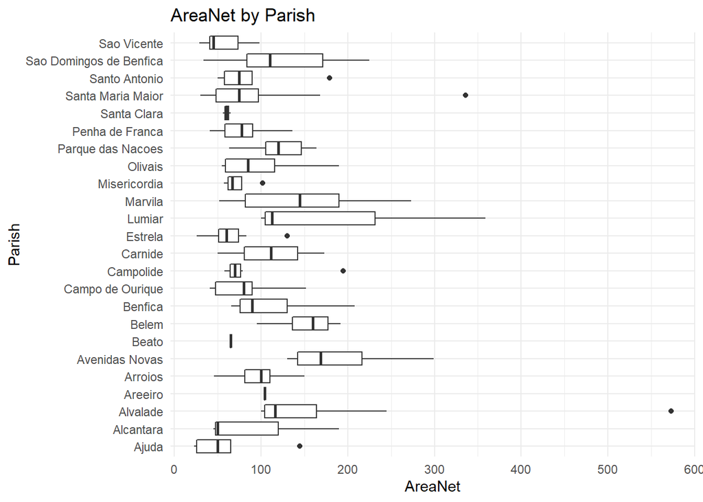

Wielkość domów w “Marvila” jest zdecydowanie większa.

## 3.4 Mapy

### 3.4.1 Stan posiadłości

[interactive chart not shown]

Można zauważyć, że blisko morza jest wiele domów nowych, a w centrum dużo domów “jak nowych”.

### 3.4.2 Podtyp posiadłości

[interactive chart not shown]

Apartamenty, których jest większość, występują w każdej dzielnicy miasta.

### 3.4.3 Powierzchnia netto

[interactive chart not shown]

Mniejsze domy są w centrum i przy wybrzeżu.

### 3.4.4 Cena za posiadłość

[interactive chart not shown]

Co ciekawe wcale nie jest tak, że w centrym są najdroższe domy.

### 3.4.5 Cena za m2

[interactive chart not shown]

Ale już za metr kwadratowy są najdroższe w centrum. W zbiorze danych cena na m2 jest ściśle związana z parafią, to jeszcze to nam wyznacza poszczególne dzielnice i domy w nich.